# Peptide Data Template

May 11, 2021

## Upload Data

### *Expression Data*

An **unlabelled** peptide expression data file called **“pep_edata.csv”** was uploaded to pmart. The column that designates unique molecules was marked as **“Mass_Tag_ID”**. The original scale of the data was **raw intensity** and was transformed to **log2**. The value to denote missing data was **“NA”** and the expression data **was not** normalized.

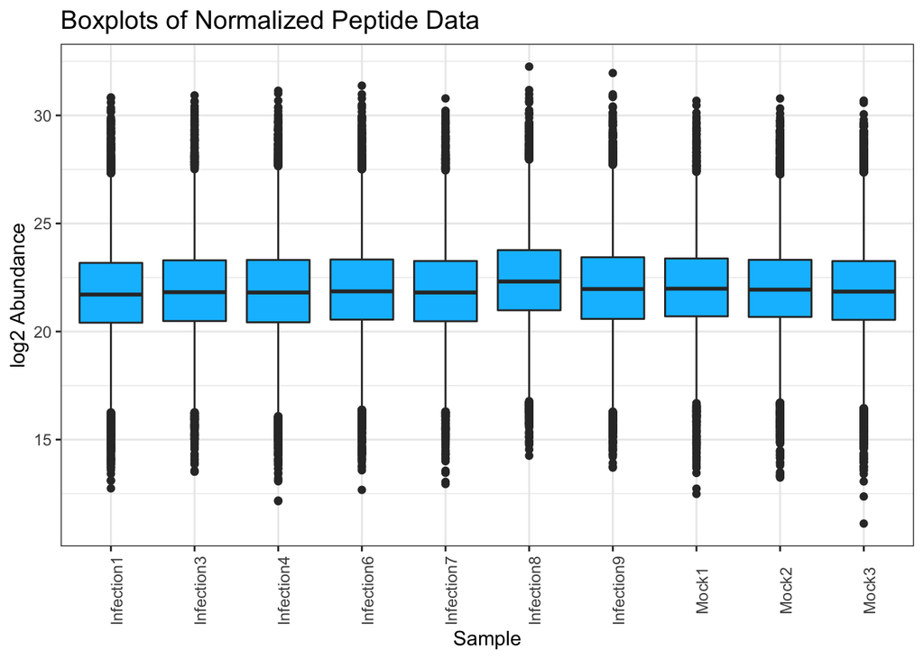

### *Biomolecule Information*

An associated biomolecule information file was also uploaded called **“pep_emeta.csv”** and the protein identifier column was designated as **“Protein”**.

## Group Samples

### *Sample Information*

An associated sample information file was also uploaded called **“pep_fdata.csv”**. This metadata file **does** contain peptide to protein mappings. Trimmed sample names **were not** used. The column in the sample information file which indicates sample names was designated as **“SampleID”**.

### *Grouping Information*

| Effect or Covariate | Set Value |
| --- | --- |
| First Main Effect | Condition |
| Second Main Effect | None |
| First Covariate | None |
| Second Covariate | None |

This table summarizes all the user specified main effects or covariates in pmart. The “Set Value” column denotes the name of the column in the “Sample Information” file assigned as a main effect or covariate.

### *Number of Samples per Main Effects*

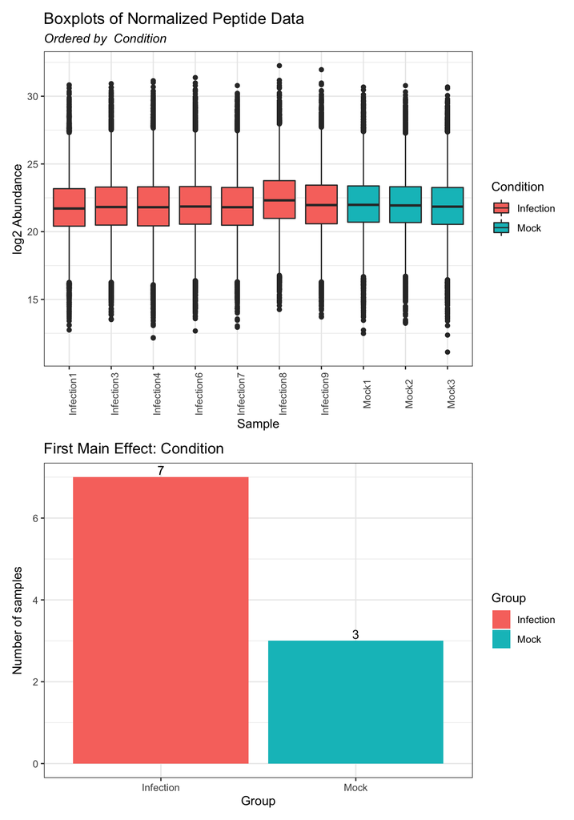

## Data Summary

### *Summary Table*

|  | Data |
| --- | --- |
| Class | pepData |
| Unique SampleIDs (f_data) | 10 |
| Unique Mass_Tag_IDs (e_data) | 13022 |
| Unique Proteins (e_meta) | 1736 |
| Missing Observations | 35221 |
| Proportion Missing | 0.27 |
| Samples per group: Infection | 7 |
| Samples per group: Mock | 3 |

The first column denotes a property of the peptide data, and the “Data” column reveals that properties’ value.

### *Missing Value Table*

|  | Missing Observations | Proportion Missing |
| --- | --- | --- |
| Infection1 | 2620 | 0.201 |
| Infection3 | 3446 | 0.265 |
| Infection4 | 3978 | 0.305 |
| Infection6 | 3534 | 0.271 |
| Infection7 | 2896 | 0.222 |
| Infection8 | 6015 | 0.462 |
| Infection9 | 4953 | 0.380 |
| Mock1 | 2680 | 0.206 |
| Mock2 | 2550 | 0.196 |
| Mock3 | 2549 | 0.196 |

The first column denotes the sample and the second is the missing number of observations. The third column represents the second as a percentage of the total number of observations for that sample.

## Filter

Filters **were** applied.

### *Summary of Applied Filters*

| Filter | Type | Parameters |
| --- | --- | --- |
| Molecule Filter | Biomolecule | Molecule Number Min: 2 |
| CV Filter | Biomolecule | Max CV: 150 |
| imd-ANOVA Filter | Biomolecule | ANOVA Min: 2 & G-test Min: 3 |
| Proteomics Filter | Biomolecule | Peptide Number Min: 2 & Remove Degenerates: Yes |
| rMD Filter | Sample | P-Value Threshold: 0.001 & Outlier Metrics: MAD, Kurtosis, Skewness, Correlation |
| Custom Filter | Sample | Samples with Infection5 were removed. |

### *Molecule Filter*

A molecule filter **was** applied. A molecule filter was applied to the data, removing Mass_Tag_IDs that were present in fewer than 2 samples. A total of 1814 Mass_Tag_IDs were filtered out of the dataset by this filter.

### *CV Filter*

A CV filter **was** applied. A coefficient of variation (CV) filter was applied to the data, removing Mass_Tag_IDs with a CV greater than 150. A total of 2 Mass_Tag_IDs were filtered out of the dataset by this filter.

### *imd-ANOVA Filter*

A imd-ANOVA filter **was** applied. An ANOVA filter was applied to the data, removing Mass_Tag_IDs that do not have at least 2 non-missing values per group. Additionally, an IMD (independence of missing data) filter was applied to the data, removing Mass_Tag_IDs that do not have at least 3 non-missing values in at least one of the groups specified in the group_DF attribute of the dataset. A total of 1861 Mass_Tag_IDs were filtered out of the dataset by this filter.

### *Proteomics Filter*

A proteomics filter **was** applied. A degenerate peptide filter was applied to the data, identifying Mass_Tag_IDs that map to more than one Protein. The filter identified 0 such Mass_Tag_IDs in the data. Associated with these Mass_Tag_IDs were 0 Proteins that no longer had Mass_Tag_IDs mapping to them. Additionally, a protein filter was applied to the data, identifying Proteins that do not have at least 2 Mass_Tag_IDs mapping to them. This filter identified 952 Proteins from the data. Associated with these Proteins were 708 Mass_Tag_IDs that no longer mapped to a Protein. Together, the two filters removed 708 Mass_Tag_IDs and 952 Proteins from the data.

### *rMD Filter*

A rMD filter **was** applied. A robust Mahalanobis distance (rMd) filter was applied to the data, removing SampleIDs with an rMd-associated p-value less than 0.001. A total of 1 SampleIDs were filtered out of the dataset by this filter.

### *Custom Filter*

A custom filter **was** applied. A custom filter was applied to the data, removing 0 Mass_Tag_IDs from e_data, 0 Proteins from e_meta, and 1 SampleIDs from f_data.

## Normalization

Peptide data **was** normalized.

### *Manual*

Manual normalization **was** used to normalize the data.

| Attribute | Value |
| --- | --- |
| Subset Function | los |
| Subset Parameters | los: 0.05 |
| Normalization Function | mean |

### *SPANS*

Could not get SPANS to run without error. Error in makePSOCKcluster(names = spec, …) : Cluster setup failed. 8 of 8 workers failed to connect.

## Protein Rollup

Could not get Protein Rollup to run without error. Error in makePSOCKcluster(names = spec, …): Cluster setup failed. 7 of 7 workers failed to connect.

## Analysis

| Attribute | Value |
| --- | --- |
| Test Method | anova |
| Multiple Comparison Adjustment | holm |
| Significance Threshold | 0.05 |